# Party Error Predictions

Haley Reed

7/17/2020

## Introduction

In looking at election forecasting models, we can seek to interpret party error. As defined by:

$$DemocraticError = DemocraticCanditatePollingPercent-DemocraticActualPercentage$$

$$RepublicanError = RepublicanCanditatePollingPercent-RepublicanActualPercentage$$

How can we go about doing so? There are several variables but year, pollster, and the number of undecided voters being polled can certainly help predict the party error of a poll. Additionally, democratic error and rebulican error are correlated enough that we express either one as a function of another. See “Margin versus Party Error.Rmd” for development of these ideas.

With that in mind, we will seek to ultimately build a Bayesian model. First let’s explore with Fisherian models.

## Fisherian Models

|  | repBias |  |  | repBias |  |  | repBias |  |  |
| --- | --- | --- | --- | --- | --- | --- | --- | --- | --- |
| Predictors | Estimates | CI | p | Estimates | CI | p | Estimates | CI | p |
| (Intercept) | -0.51 | -0.97 – -0.04 | **0.034** | -1.83 | -2.43 – -1.24 | **<0.001** | -2.24 | -3.00 – -1.48 | **<0.001** |
| demBias | -0.81 | -0.88 – -0.74 | **<0.001** | -0.88 | -0.98 – -0.77 | **<0.001** | -0.88 | -1.02 – -0.74 | **<0.001** |
| year [2004] | -0.39 | -0.86 – 0.08 | 0.107 | -0.28 | -0.75 – 0.19 | 0.237 | -0.45 | -1.52 – 0.61 | 0.404 |
| year [2008] | 0.27 | -0.21 – 0.74 | 0.270 | 0.13 | -0.35 – 0.61 | 0.602 | -0.74 | -2.00 – 0.51 | 0.244 |
| year [2012] | 0.97 | 0.43 – 1.51 | **<0.001** | 0.65 | 0.09 – 1.22 | **0.024** | 2.07 | 0.57 – 3.57 | **0.007** |
| year [2016] | 1.43 | 0.95 – 1.91 | **<0.001** | 1.10 | 0.54 – 1.66 | **<0.001** | 0.23 | -1.25 – 1.71 | 0.760 |
| undecided | -0.53 | -0.56 – -0.50 | **<0.001** | -0.49 | -0.52 – -0.46 | **<0.001** | -0.42 | -0.45 – -0.39 | **<0.001** |
| demBias * year [2004] | 0.09 | -0.02 – 0.19 | 0.113 | 0.06 | -0.05 – 0.18 | 0.282 | -0.03 | -0.30 – 0.23 | 0.803 |
| demBias * year [2008] | -0.01 | -0.11 – 0.08 | 0.793 | -0.03 | -0.13 – 0.08 | 0.588 | 0.01 | -0.26 – 0.27 | 0.963 |
| demBias * year [2012] | 0.04 | -0.09 – 0.18 | 0.530 | 0.03 | -0.11 – 0.17 | 0.681 | 0.26 | -0.04 – 0.56 | 0.085 |
| demBias * year [2016] | 0.02 | -0.07 – 0.12 | 0.621 | 0.07 | -0.06 – 0.21 | 0.289 | -0.10 | -0.45 – 0.26 | 0.596 |
| pollster [PblcPlP] |  |  |  | 1.80 | 1.22 – 2.38 | **<0.001** | 2.56 | 1.00 – 4.12 | **0.001** |
| pollster [RRp-POR] |  |  |  | 1.60 | 1.09 – 2.10 | **<0.001** | -0.70 | -1.71 – 0.32 | 0.179 |
| pollster [SrvyMnk] |  |  |  | 0.95 | 0.35 – 1.55 | **0.002** | 1.26 | -0.07 – 2.59 | 0.063 |
| pollster [SrvyUSA] |  |  |  | 1.34 | 0.83 – 1.86 | **<0.001** | 2.65 | 1.40 – 3.90 | **<0.001** |
| pollster [YouGov] |  |  |  | 0.95 | 0.37 – 1.53 | **0.001** | 1.23 | -0.27 – 2.74 | 0.108 |
| pollster [ZIn-JZA] |  |  |  | 0.92 | 0.40 – 1.43 | **0.001** | 0.97 | 0.06 – 1.88 | **0.037** |
| demBias * pollster [PblcPlP] |  |  |  | 0.01 | -0.18 – 0.20 | 0.911 | 0.09 | -0.51 – 0.70 | 0.760 |
| demBias * pollster [RRp-POR] |  |  |  | 0.18 | 0.07 – 0.29 | **0.002** | 0.02 | -0.16 – 0.19 | 0.848 |
| demBias * pollster [SrvyMnk] |  |  |  | 0.00 | -0.16 – 0.17 | 0.972 | 0.19 | -0.15 – 0.52 | 0.274 |
| demBias * pollster [SrvyUSA] |  |  |  | -0.07 | -0.21 – 0.07 | 0.313 | 0.03 | -0.25 – 0.30 | 0.856 |
| demBias * pollster [YouGov] |  |  |  | -0.04 | -0.19 – 0.10 | 0.576 | 0.01 | -0.40 – 0.41 | 0.979 |
| demBias * pollster [ZIn-JZA] |  |  |  | 0.09 | -0.03 – 0.21 | 0.150 | 0.13 | -0.05 – 0.32 | 0.155 |
| year [2008] * pollster [PblcPlP] |  |  |  |  |  |  | 0.25 | -1.84 – 2.33 | 0.805 |
| year [2012] * pollster [PblcPlP] |  |  |  |  |  |  | -1.91 | -3.34 – -0.47 | 0.073 |
| year [2004] * pollster [RRp-POR] |  |  |  |  |  |  | 1.89 | 0.05 – 3.72 | **0.010** |
| year [2008] * pollster [RRp-POR] |  |  |  |  |  |  | 3.68 | 1.95 – 5.40 | **<0.001** |
| year [2012] * pollster [RRp-POR] |  |  |  |  |  |  | 0.99 | -0.53 – 2.51 | 0.289 |
| year [2016] * pollster [RRp-POR] |  |  |  |  |  |  | 2.42 | 0.72 – 4.12 | **0.006** |
| year [2004] * pollster [SrvyUSA] |  |  |  |  |  |  | -0.78 | -2.93 – 1.36 | 0.311 |
| year [2008] * pollster [SrvyUSA] |  |  |  |  |  |  | -0.82 | -2.07 – 0.43 | 0.343 |
| year [2012] * pollster [SrvyUSA] |  |  |  |  |  |  | -3.65 | -5.16 – -2.15 | **0.002** |
| year [2016] * pollster [SrvyUSA] |  |  |  |  |  |  | 0.86 | -1.13 – 2.85 | 0.410 |
| year [2004] * pollster [YouGov] |  |  |  |  |  |  | -0.40 | -1.14 – 0.33 | 0.790 |
| year [2008] * pollster [YouGov] |  |  |  |  |  |  | 0.90 | 0.21 – 1.59 | 0.347 |
| year [2012] * pollster [YouGov] |  |  |  |  |  |  | -1.84 | -2.26 – -1.43 | 0.092 |
| year [2004] * pollster [ZIn-JZA] |  |  |  |  |  |  | 0.09 | -0.31 – 0.48 | 0.893 |
| year [2008] * pollster [ZIn-JZA] |  |  |  |  |  |  | 0.72 | 0.32 – 1.12 | 0.349 |
| year [2012] * pollster [ZIn-JZA] |  |  |  |  |  |  | -1.39 | -1.78 – -0.99 | 0.171 |
| (demBias * year [2008]) * pollster [PblcPlP] |  |  |  |  |  |  | -0.08 | -0.59 – 0.43 | 0.825 |
| (demBias * year [2012]) * pollster [PblcPlP] |  |  |  |  |  |  | -0.28 | -0.76 – 0.19 | 0.420 |
| (demBias * year [2004]) * pollster [RRp-POR] |  |  |  |  |  |  | 0.09 | -0.22 – 0.40 | 0.656 |
| (demBias * year [2008]) * pollster [RRp-POR] |  |  |  |  |  |  | 0.01 | -0.32 – 0.33 | 0.975 |
| (demBias * year [2012]) * pollster [RRp-POR] |  |  |  |  |  |  | -0.31 | -0.83 – 0.21 | 0.129 |
| Observations | 944 |  |  | 944 |  |  | 944 |  |  |
| R<sup>2</sup> / R<sup>2</sup> adjusted | 0.801 / 0.799 |  |  | 0.821 / 0.817 |  |  | 0.852 / 0.843 |  |  |

## Bayesian Modeling

In this example of Bayesian modeling, year and pollster were used as nominal predictors for democratic bias and republican bias was modeling with the two numeric variables of modeled democratic bias and the number of undecided voters.

The summary for this model is provided below:

[output not shown]

[output cut: 69 more lines]

The post predictive plot for democratic bias for 2016 is shown for reference:

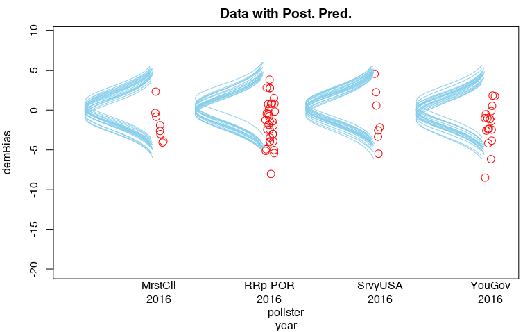

The Predictions for the coefficients of the rebulican model is shown below:

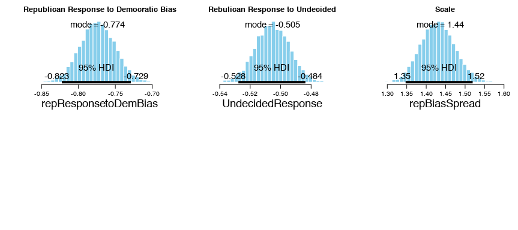